# Ejercicio de clase 3

Lenin Pavón

2025-09-14

# Ejercicio 1

Cargamos los archivos teniendo directorio de trabajo `statistics`.

```r
indicadores <- data.frame(read.csv("data/Indicadores.csv"))
senDistElec <- data.frame(read.csv("data/SenDistElec.csv"))
```

Vemos que como comparten la columna `ID_Distrito`, podemos fusionarlos con `merge`

```r
df <- merge(indicadores, senDistElec, by = "ID_Distrito")
```

# Ejercicio 2

Vamos a calcular ahora el porcentaje a favor de la coalición PVEM-PT-MORENA. Como se puede votar ya sea por la coalición, candidatos comunes, o por un solo partido hay que sumar las siguientes columnas:

- `PVEM.PT.MORENA`
- `PVEM.PT`
- `PVEM.MORENA`
- `PVEM`
- `PT`
- `MORENA`

```r
df$aprobacion <- with(
  df,
  (PVEM.PT.MORENA + PVEM.PT + PVEM.MORENA + PVEM + PT + MORENA) / TOTAL_VOTOS_CALCULADOS
)
```

# Ejercicio 3

## Graficación

Graficando

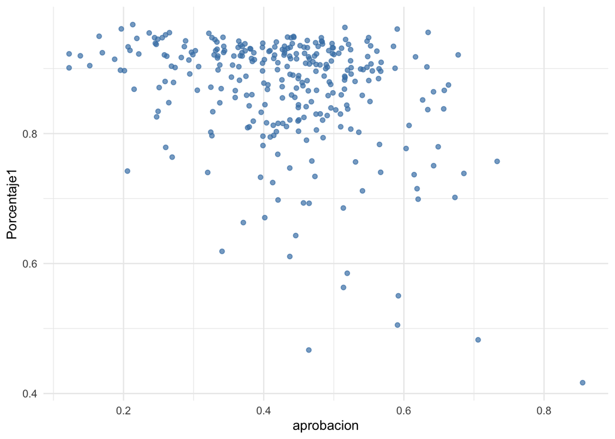

```r
library(ggplot2)

ggplot(df, aes(aprobacion,Porcentaje1)) +
  geom_point(alpha = 0.7, color = "steelblue") +
  theme_minimal()
```

Vemos que en los distritos con baja aprobación ($<0.6$) de la coalición suele haber un alto porcentaje de viviendas particulares habitadas que disponen de teléfono celular

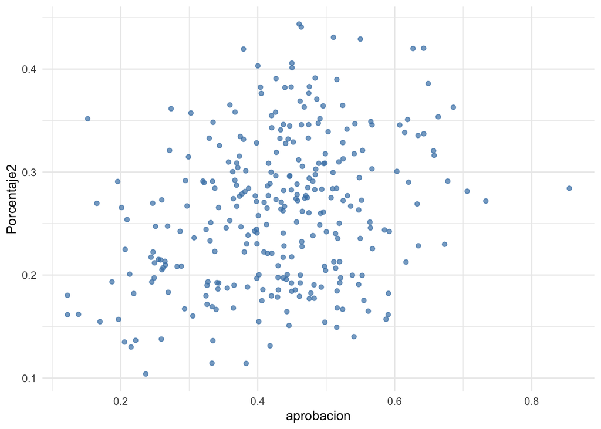

```r
library(ggplot2)

ggplot(df, aes(aprobacion,Porcentaje2)) +
  geom_point(alpha = 0.7, color = "steelblue") +
  theme_minimal()
```

Vemos que a muy grandes rasgos, entre mayor es la aprobación de la coalición, suele haber un mayor porcentaje de población sin afiliación a servicios de salud.

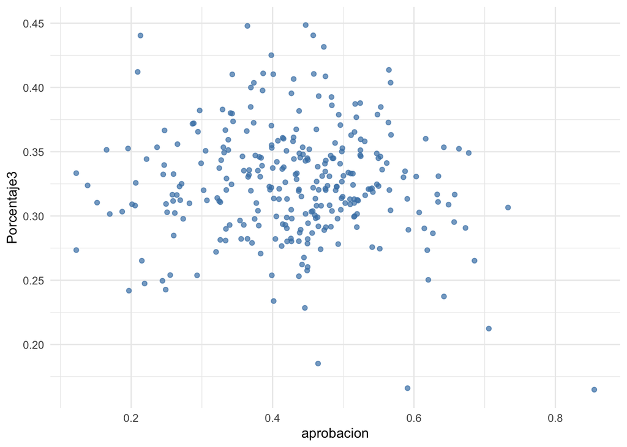

```r
library(ggplot2)

ggplot(df, aes(aprobacion,Porcentaje3)) +
  geom_point(alpha = 0.7, color = "steelblue") +
  theme_minimal()
```

No hay una relación clara entre el porcentaje de aprobación de la coalición y el porcentaje de hogares censales con persona de referencia mujer.

# Ejercicio 4

```r
library(dplyr)
df %>%
  summarise(
    mean   = mean(aprobacion, na.rm = TRUE),
    median = median(aprobacion, na.rm = TRUE),
    sd     = sd(aprobacion, na.rm = TRUE),
    count  = n()
  )
```

| mean | median | sd | count |
| --- | --- | --- | --- |
| 0.4299921 | 0.438107 | 0.1177329 | 300 |

Vemos que no hay una mayoría de aprobación, además de que (proporcionalmente hablando) los resultados tienen una desviación estandar muy elevada.

# Ejercicio 5

(Johan escribí esto a las 2 de la mañana no me odies) Con base en las listas de los estados en cada circunscripción, agrupamos los datos con base en este dato y graficamos como hicimos anteriormente.

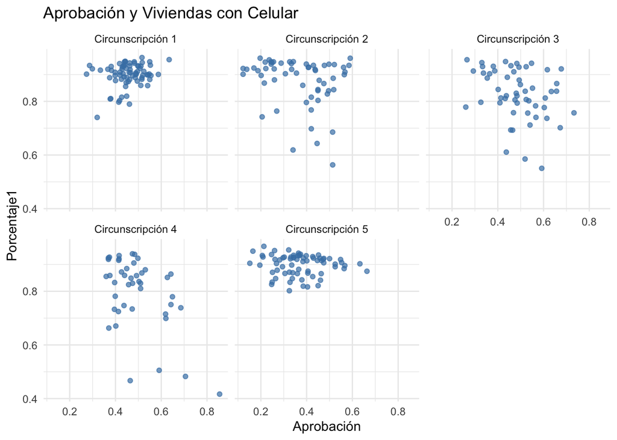

```r
library(dplyr)
library(ggplot2)

# Definir las circunscripciones por IDs
circunscripciones <- list(
  circ_1 = c(2, 3, 6, 10, 15, 18, 25, 26),        # Primera
  circ_2 = c(1, 8, 12, 19, 22, 24, 28, 32),       # Segunda
  circ_3 = c(4, 5, 20, 23, 27, 30, 31),           # Tercera
  circ_4 = c(7, 13, 17, 21, 29),                  # Cuarta
  circ_5 = c(9, 14, 11, 16)                       # Quinta
)

# Crear una columna con la circunscripción correspondiente
df <- df %>%
  mutate(Circunscripcion = case_when(
    ID_Entidad %in% circunscripciones$circ_1 ~ "Circunscripción 1",
    ID_Entidad %in% circunscripciones$circ_2 ~ "Circunscripción 2",
    ID_Entidad %in% circunscripciones$circ_3 ~ "Circunscripción 3",
    ID_Entidad %in% circunscripciones$circ_4 ~ "Circunscripción 4",
    ID_Entidad %in% circunscripciones$circ_5 ~ "Circunscripción 5",
    TRUE ~ "Otro"
  ))

# Graficar scatter plots para cada circunscripción
ggplot(df, aes(x = aprobacion, y = Porcentaje1)) +
  geom_point(alpha = 0.7, color = "steelblue") +
  facet_wrap(~ Circunscripcion) +
  labs(
    title="Aprobación y Viviendas con Celular",
    x = "Aprobación",
    y = "Porcentaje1"
  ) +
  theme_minimal()
```

En esta primera gráfica vemos que las circunscripciones 1 y 5 no muestran cambios significactivos conforme aumenta la aprobación. Pero en las demás circunscripciones podemos observar que disminuye el porcentaje de viviendas habitadas que disponen de teléfono celular.

[figure not shown]

```r
ggplot(df, aes(x = aprobacion, y = Porcentaje1)) +
  geom_point(alpha = 0.7, color = "steelblue") +
  facet_wrap(~ Circunscripcion) +
  labs(
    title="Aprobación y Población sin afliciación a servicios de salud",
    x = "Aprobación",
    y = "Porcentaje2"
  ) +
  theme_minimal()
```

[figure not shown]

```r
ggplot(df, aes(x = aprobacion, y = Porcentaje1)) +
  geom_point(alpha = 0.7, color = "steelblue") +
  facet_wrap(~ Circunscripcion) +
  labs(
    title="Aprobación y Hogares censales",
    x = "Aprobación",
    y = "Porcentaje3"
  ) +
  theme_minimal()
```